# Introduction to R package SC19057

### 2019.12.20

#### Question

You have already written an R function for Exercise 9.4 (page 277, Statistical Computing with R). Rewrite an Rcpp function for the same task.  
(1)Compare the generated random numbers by the two functions using qqplot.  
(2) Campare the computation time of the two functions with microbenchmark.  
(3) Comments your results.

#### Answer

Both functions are showed in the code below. By compare the results of two functions and their qqplot, we can find that the chains generated by two functions are similar (while sigma is small, the chain is not good and the chains generated by two functions may different). However, compare the computing time, we can easily find that the cpp function is more efficient than R function under different sigma. Thus, The cpp function performs better than R function in this case.

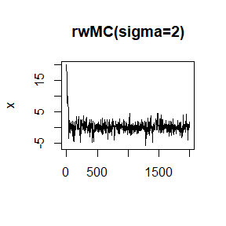

```r
library(Rcpp)
library(microbenchmark)
#define cpp function
cppFunction('NumericMatrix rwMC(double sigma, double x0, int N){
  NumericMatrix x(N,2);
  x(0,0) = x0;
  x(0,1) = 1;
  NumericVector u(N);
  u=runif(N);
  for (int i=1;i<N; i++) {
    double y = rnorm(1, x[i-1], sigma)[0];
    double t = exp(-abs(y)) / exp(-abs(x[i-1]));
      if (u[i] <= t) {
        x(i,0) = y;
        x(i,1) = 1;
      }else {
        x(i,0) = x(i-1,0);
        x(i,1) = 0;
      }
  };
  return x;
}')
#define R function
rwMR <- function(sigma, x0, N){
  x <- numeric(N)
  x[1] <- x0
  u <- runif(N)
  k <- 0
  for (i in 2:N) {
    y <- rnorm(1, x[i-1], sigma)
    if (u[i] <= (exp(-abs(y)) / exp(-abs(x[i-1])))) x[i] = y
    else {
      x[i] = x[i-1]
      k = k+1
    }
  }
  return(list(x = x, k = k))
}
# the plot with sigma=2
out1<-rwMC(2,20,2000)
out2<-rwMR(2,20,2000)
plot(out1[,1], type="l", main='rwMC(sigma=2)', ylab="x",xlab = "")
```

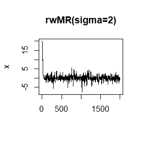

```r
plot(out2$x,type="l", main='rwMR(sigma=2)', ylab="x",xlab = "")
```

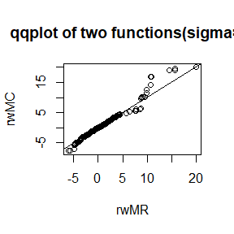

```r
#compare the generated random numbers
qqplot(out1[,1],out2$x,xlab = 'rwMR',ylab = 'rwMC',main='qqplot of two functions(sigma=2)')
abline(a=0,b=1)
```

```r
#compare the computation time
ts <- microbenchmark(r=rwMR(2,20,2000),cpp=rwMC(2,20,2000))
summary(ts)
```

```
##   expr    min     lq     mean  median     uq     max neval
## 1    r 5285.1 6359.2 7547.962 6787.35 7199.2 14703.4   100
## 2  cpp  374.7  444.0  532.259  457.15  468.8  6467.3   100
```

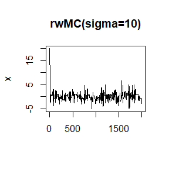

```r
# the plot with sigma=10
out1<-rwMC(10,20,2000)
out2<-rwMR(10,20,2000)
plot(out1[,1], type="l", main='rwMC(sigma=10)', ylab="x",xlab = "")
```

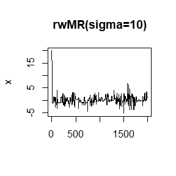

```r
plot(out2$x,type="l", main='rwMR(sigma=10)', ylab="x",xlab = "")
```

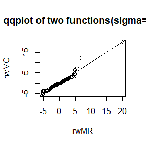

```r
#compare the generated random numbers
qqplot(out1[,1],out2$x,xlab = 'rwMR',ylab = 'rwMC',main='qqplot of two functions(sigma=10)')
abline(a=0,b=1)
```

```r
#compare the computation time
ts <- microbenchmark(r=rwMR(10,20,2000),cpp=rwMC(10,20,2000))
summary(ts)
```

```
##   expr    min      lq     mean  median      uq     max neval
## 1    r 5313.6 6503.25 7708.513 6952.80 7580.70 14230.3   100
## 2  cpp  409.2  460.85  494.171  471.95  487.05   957.8   100
```

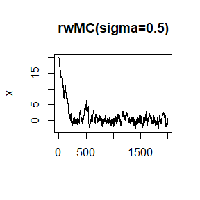

```r
# the plot with sigma=0.5
out1<-rwMC(0.5,20,2000)
out2<-rwMR(0.5,20,2000)
plot(out1[,1], type="l", main='rwMC(sigma=0.5)', ylab="x",xlab = "")
```

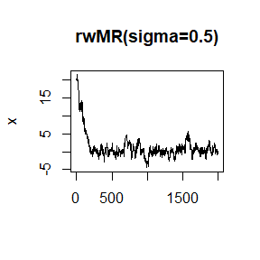

```r
plot(out2$x,type="l", main='rwMR(sigma=0.5)', ylab="x",xlab = "")
```

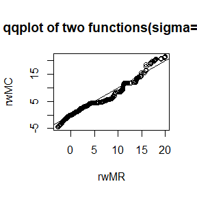

```r
#compare the generated random numbers
qqplot(out1[,1],out2$x,xlab = 'rwMR',ylab = 'rwMC',main='qqplot of two functions(sigma=0.5)')
abline(a=0,b=1)
```

```r
#compare the computation time
ts <- microbenchmark(r=rwMR(0.5,20,2000),cpp=rwMC(0.5,20,2000))
summary(ts)
```

```
##   expr    min      lq     mean  median      uq     max neval
## 1    r 5679.0 6517.60 7461.443 6988.85 7327.10 14316.6   100
## 2  cpp  362.7  413.95  435.762  425.40  442.35   735.6   100
```